# Practical Machine Learning Assignment

Matthew Birch

23 August 2015

### Objective

**Note that it is assumed for the purspose of this exercise that ALL variables in the training and test set may be used to estimate the out of sample classification. This includes the timing variables for each observation as well as the test subject.**

Data source: Velloso, E.; Bulling, A.; Gellersen, H.; Ugulino, W.; Fuks, H. Qualitative Activity Recognition of Weight Lifting Exercises. Proceedings of 4th International Conference in Cooperation with SIGCHI (Augmented Human ’13) . Stuttgart, Germany: ACM SIGCHI, 2013.

### Initial variable inspection

Training data comprised 19,622 observations of 158 predictor variables, as well as the class variable. Before any data exploration, the training data provided were split into a training and testing set, at ratio of 0.75:0.25. **Data exploration was then limited to the training subset only**.

```r
#load training data
pml.training <- read.csv("~/Personal Work/Coursera/pml-training.csv",row.names=1)
#determine variable classes of training data
classes<-sapply(pml.training,class)
#load testing data ensuring same variable structure as training set
pml.testing <- read.csv("~/Personal Work/Coursera/pml-testing.csv",row.names=1,colClasses = classes)

# set seed for reproducability
set.seed(23687)
# split traing data into training and testing subsets
inTrain = createDataPartition(pml.training$classe, p = 0.75, list=FALSE)
training = pml.training[ inTrain,]
testing = pml.training[-inTrain,]
```

Viewing a summary of the predictor variables highlights that a large number of variables include blank entries, and NA values. Further, the variable names of many of these such predictors suggests that the would-be values are summary statistics based on other predictor variables (e.g. averages, maximums, kurtosis, skews etc).

Removing those predictor variables with majority NAs and blanks results in a reduction of predictor variables from 158 to 58 listed below:

```r
# identify variables with multiple blank entries
ls <- apply(training,2,function(x) sum((x=="")))
# create a list of variables with non-blank, non-NA entries
vars_full <- c(names(subset(ls, ls == 0)))
# remove class variables from list
vars_full <- vars_full[c(-59)]

print(vars_full)
```

```
##  [1] "user_name"            "raw_timestamp_part_1" "raw_timestamp_part_2"
##  [4] "cvtd_timestamp"       "new_window"           "num_window"
##  [7] "roll_belt"            "pitch_belt"           "yaw_belt"
## [10] "total_accel_belt"     "gyros_belt_x"         "gyros_belt_y"
## [13] "gyros_belt_z"         "accel_belt_x"         "accel_belt_y"
## [16] "accel_belt_z"         "magnet_belt_x"        "magnet_belt_y"
## [19] "magnet_belt_z"        "roll_arm"             "pitch_arm"
## [22] "yaw_arm"              "total_accel_arm"      "gyros_arm_x"
## [25] "gyros_arm_y"          "gyros_arm_z"          "accel_arm_x"
## [28] "accel_arm_y"          "accel_arm_z"          "magnet_arm_x"
## [31] "magnet_arm_y"         "magnet_arm_z"         "roll_dumbbell"
## [34] "pitch_dumbbell"       "yaw_dumbbell"         "total_accel_dumbbell"
## [37] "gyros_dumbbell_x"     "gyros_dumbbell_y"     "gyros_dumbbell_z"
## [40] "accel_dumbbell_x"     "accel_dumbbell_y"     "accel_dumbbell_z"
## [43] "magnet_dumbbell_x"    "magnet_dumbbell_y"    "magnet_dumbbell_z"
## [46] "roll_forearm"         "pitch_forearm"        "yaw_forearm"
## [49] "total_accel_forearm"  "gyros_forearm_x"      "gyros_forearm_y"
## [52] "gyros_forearm_z"      "accel_forearm_x"      "accel_forearm_y"
## [55] "accel_forearm_z"      "magnet_forearm_x"     "magnet_forearm_y"
## [58] "magnet_forearm_z"
```

Given non-numeric nature of ‘cvtd_ timestamp’ this variable is also removed from consideration and is assumed to have been generated as a combination of one or both of the ‘raw_time…’ variables.

Given the size of the data and possible number of permuations of variables, instead of identifying linear dependency or correlation between predictors it was instead decided to make use of a non-linear machine learning algorithm (random forests) and rather use feaure importance as a feature selection method.

### Initial training and predictor selection

Initial model training was conducted using all 57 of the predictors identified above (after removal of cvtd_ timestamp). The method used was a Random Forest, using 5-fold cross validation on the training subset to reduce risk of over-fitting.

```r
# set training control for cross validation, 5 folds
control = trainControl(method = "cv", number = 5)
# train random forest model on training set using cross validation
rf<-train(x = training[,vars],y=training$classe,method="rf", trControl=control)
```

```
## Random Forest
##
## 14718 samples
##    57 predictor
##     5 classes: 'A', 'B', 'C', 'D', 'E'
##
## No pre-processing
## Resampling: Cross-Validated (5 fold)
## Summary of sample sizes: 11775, 11774, 11774, 11774, 11775
## Resampling results across tuning parameters:
##
##   mtry  Accuracy   Kappa      Accuracy SD   Kappa SD
##    2    0.9960592  0.9950151  0.0008184627  0.001035497
##   29    0.9989128  0.9986248  0.0008112722  0.001026207
##   57    0.9982333  0.9977653  0.0011621589  0.001470107
##
## Accuracy was used to select the optimal model using  the largest value.
## The final value used for the model was mtry = 29.
```

Despite near 100% accuracy, the importance of individual predictor variables was plotted, both to better understand model prediction and also to facilitate model simplification:

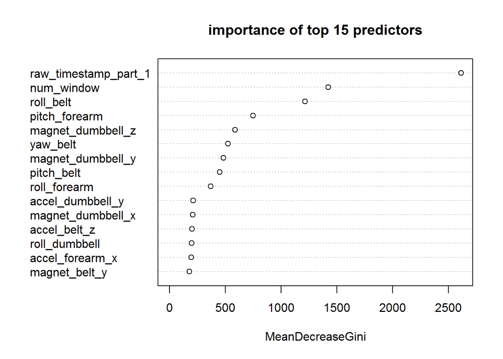

```r
# calculate and plot importance of variables based on cross validated model
importance <- varImp(rf,scale=F)
varImpPlot(rf$finalModel,n.var=15,main="importance of top 15 predictors")
```

A step change in importance is visible after the top 1, 3 and 9 variables. Given that 2 of the top 3 variables are time related suggests high correlation between timing of data readings and the classification of the exercise type (classe variable) - this intuitively makes sense given high frequency of data sampling i.e. any randomly chosen “test” observation of the predictor variables will have been sampled at almost the same time as a “training” observation of known classe. Thus, classification of randomly selected observations is almost entirely predictable knowing only the time at whch the sample occured.

### Final model

Given high predictive importance, a new model was specified using only the top 3 predictors:

```r
#creaste list of variables in descending order of importance
ranked_vars <- row.names(importance$importance[order(-importance$importance$Overall),0])
#build model using top 3 predictors
test <- train(x = training[,ranked_vars[1:3]],y=training$classe,method="rf", trControl=control)
```

```
## Random Forest
##
## 14718 samples
##     3 predictor
##     5 classes: 'A', 'B', 'C', 'D', 'E'
##
## No pre-processing
## Resampling: Cross-Validated (5 fold)
## Summary of sample sizes: 11775, 11775, 11774, 11774, 11774
## Resampling results across tuning parameters:
##
##   mtry  Accuracy   Kappa      Accuracy SD   Kappa SD
##   2     0.9997962  0.9997422  0.0003038136  0.0003842585
##   3     0.9997962  0.9997422  0.0003038136  0.0003842585
##
## Accuracy was used to select the optimal model using  the largest value.
## The final value used for the model was mtry = 2.
```

### Out-of-sample validation

As a final check for over-fitting, and as an additional estimate of out-of sample error, the reduced model was fitted to the test subset created at the beginning of the exercise, and the confusion matrix calculated (see below). Overall accuracy on the pseudo out of sample data was 0.9912, which could suggest very minor (bordering on negligible) over-fitting.

```r
# predict classes on testing subset
preds <- predict(test, newdata = as.data.frame(testing[,ranked_vars[1:3]]))
# check accuarcy of predictions
cf<-confusionMatrix(preds,testing$classe)
cf
```

```
## Confusion Matrix and Statistics
##
##           Reference
## Prediction    A    B    C    D    E
##          A 1386    7    0    0    0
##          B    9  939    9    0    0
##          C    0    3  837    1    0
##          D    0    0    9  798    0
##          E    0    0    0    5  901
##
## Overall Statistics
##
##                Accuracy : 0.9912
##                  95% CI : (0.9882, 0.9936)
##     No Information Rate : 0.2845
##     P-Value [Acc > NIR] : < 2.2e-16
##
##                   Kappa : 0.9889
##  Mcnemar's Test P-Value : NA
##
## Statistics by Class:
##
##                      Class: A Class: B Class: C Class: D Class: E
## Sensitivity            0.9935   0.9895   0.9789   0.9925   1.0000
## Specificity            0.9980   0.9954   0.9990   0.9978   0.9988
## Pos Pred Value         0.9950   0.9812   0.9952   0.9888   0.9945
## Neg Pred Value         0.9974   0.9975   0.9956   0.9985   1.0000
## Prevalence             0.2845   0.1935   0.1743   0.1639   0.1837
## Detection Rate         0.2826   0.1915   0.1707   0.1627   0.1837
## Detection Prevalence   0.2841   0.1951   0.1715   0.1646   0.1847
## Balanced Accuracy      0.9958   0.9925   0.9890   0.9952   0.9994
```

### Test-set predictions

After validation against the pseudo out-of-sample data, the 3 predictor model was applied to the 20 test observations supplied

```r
# calculate predictions for the assessment test set
predsT <- predict(test,newdata = pml.testing[,ranked_vars[1:3]])
as.data.frame(predsT)
```

```
##    predsT
## 1       B
## 2       A
## 3       B
## 4       A
## 5       A
## 6       E
## 7       D
## 8       B
## 9       A
## 10      A
## 11      B
## 12      C
## 13      B
## 14      A
## 15      E
## 16      E
## 17      A
## 18      B
## 19      B
## 20      B
```